# Hallazgos

Juan Pablo Calle Quintero

24 October 2015

```r
## Cargar librerias necesarias y funciones auxiliares

source(file = '1_cargar_librerias.R')
source(file = '2_def_funciones_aux.R')


## Lectura de datos ------------------------------------------------------------

datos_orig <- fread(input =  '../datos/datos.csv', header = TRUE)
depart <- fread(input = '../datos/departamentos.csv', header = TRUE)

# solo estudiaremos los nacimientos en un periodo de 10 años 2000-2009
periodo_estudio <- as.character(2000:2009)
datos_orig <- datos_orig[anio_nac_hijo %in% periodo_estudio]
datos_orig[, nro_hijos := .N, by = id_madre]

setkey(datos_orig, id_madre)
setkey(depart, id_dep)

tables() # ver resumen base de datos orginal
```

```
##      NAME         NROW NCOL MB
## [1,] datos_orig 36,999   60 11
## [2,] depart         33    2  1
##      COLS
## [1,] id_hogar,id_madre,peso_muestra,edad_madre,departamento,region,tipo_lugar_residen
## [2,] id_dep,dep
##      KEY
## [1,] id_madre
## [2,] id_dep
## Total: 12MB
```

```r
# Creamos dos bases de datos para comparar:
# datos_1m: contiene los datos de los hijos que han fallecido.
# datos_0m: contienen los datos de los hijos de las madres que no han perdido
#           ningún hijo.
# Note que si alguna madre perdió un hijo antes del año 2000, y no ha perdido
# hijos posteriormente, quedará dentro de la base datos_0m

si_ha_perdido_hijos12 <-
  datos_orig[edad_muerte_meses <= 12,
             .(hijos_vivos = sum(hijo_vivo_muerto) != mean(nro_hijos)),
             by = id_madre][hijos_vivos == TRUE, id_madre]

# datos_1m <- datos_orig[edad_muerte_meses <= 12 & !is.na(edad_muerte_meses)]
datos_1m <- datos_orig[id_madre %in% si_ha_perdido_hijos12]

no_ha_perdido_hijos12 <-
  datos_orig[,
             .(hijos_vivos = sum(hijo_vivo_muerto) == mean(nro_hijos)),
             by = id_madre][hijos_vivos == TRUE, id_madre]

datos_0m <- datos_orig[id_madre %in% no_ha_perdido_hijos12]

tables()
```

```
##      NAME         NROW NCOL MB
## [1,] datos_0m   35,009   60 11
## [2,] datos_1m    1,682   60  1
## [3,] datos_orig 36,999   60 11
## [4,] depart         33    2  1
##      COLS
## [1,] id_hogar,id_madre,peso_muestra,edad_madre,departamento,region,tipo_lugar_residen
## [2,] id_hogar,id_madre,peso_muestra,edad_madre,departamento,region,tipo_lugar_residen
## [3,] id_hogar,id_madre,peso_muestra,edad_madre,departamento,region,tipo_lugar_residen
## [4,] id_dep,dep
##      KEY
## [1,] id_madre
## [2,] id_madre
## [3,] id_madre
## [4,] id_dep
## Total: 24MB
```

```r
# Número de niños <= a un año fallecidos por departamento

tot_nacim <- datos_orig[, .(tot_nac = .N), by = departamento]
setkey(tot_nacim, departamento)
fallecidos_dep <- datos_1m[edad_muerte_meses <= 12,
                           .(tot_fall = .N),
                           by = departamento]
setkey(fallecidos_dep, departamento)
tbl_x_dep <- fallecidos_dep[depart][tot_nacim][, .(dep, tot_fall, tot_nac)][, prop := 100 * (tot_fall / tot_nac)][order(-tot_fall)]

xtable(tbl_x_dep)
```

```
## % latex table generated in R 3.2.2 by xtable 1.7-4 package
## % Sat Oct 24 23:12:01 2015
## \begin{table}[ht]
## \centering
## \begin{tabular}{rlrrr}
##   \hline
##  & dep & tot\_fall & tot\_nac & prop \\
##   \hline
## 1 & La Guajira &  50 & 1252 & 3.99 \\
##   2 & Chocó &  42 & 1126 & 3.73 \\
##   3 & Bogotá &  36 & 1951 & 1.85 \\
##   4 & Amazonas &  35 & 1539 & 2.27 \\
##   5 & Antioquia &  32 & 1940 & 1.65 \\
##   6 & Valle &  29 & 1931 & 1.50 \\
##   7 & Atlántico &  28 & 1208 & 2.32 \\
```

[output cut: 29 more lines]

```r
# Listas de variables con código original de la base de datos
# Importante para poder buscar las definiciones en el diccionario
# Para ver definiciones ir a: COBR61FL_BIRTH_RECODE.MAP
#                             COPR61FL_HOUSEHOLD_MEMBER_RECODE.MAP
variables_usadas_hogar <-
  list(
    id_hogar = 'hhid',
    padre_vivo = 'hv113',
    nro_habitaciones_hogar = 'hv216'
  )

variables_usadas_nacimientos <-
  list(
    id_madre = 'caseid',
    peso_muestra = 'v005',
    edad_madre = 'v012',
    departamento = 'v023', # no es de interés, solo estamos trabajando con Ant
    region = 'v024', # no es de interés, solo Ant, Central
    tipo_lugar_residencia = 'v025',
    anios_resid = 'v104',
    max_nivel_edu = 'v106',
    fuente_agua = 'v113',
    tipo_banio = 'v116',
    energia = 'v119',
    radio = 'v120',
    television = 'v121',
    nevera = 'v122',
    moto = 'v124',
    carro = 'v125',
    etnia = 'v131',
    nro_personas_hogar = 'v136',
    nro_ninios_hogar5 = 'v137',
    nro_mujeres_eleg_hogar = 'v138',
    rel_cabeza_fam = 'v150',
    sexo_cabeza_fam = 'v151',
    edad_cabeza_familia = 'v152',
    tipo_combustible_cocina = 'v161',
    hijo_nro = 'bidx',
    twin_code = 'b0',
    mes_nac_hijo = 'b1',
    anio_nac_hijo = 'b2',
    siglo_nac_hijo = 'b3',
    sexo_hijo = 'b4',
    hijo_vivo_muerto = 'b5',
    edad_muerte_meses = 'b7',
    edad_hijo_anios = 'b8',
    tpo_entre_nac_meses = 'b11',
    nro_hijos_muertos = 'v206',
    nro_hijas_muertas = 'v207',
    nro_hijos5 = 'v208',
    nro_hijos1 = 'v209',
    edad_madre_1hijo = 'v212',
    ind_embarazos_fallidos = 'v228',
    meses_embarazo_fallido = 'v233',
    tpo_amamanta_meses = 'm5',
    hijo_deseado = 'm10',
    nacimiento_cesarea = 'm17',
    peso_al_nacer_kg = 'm19',
    quien_tomo_peso = 'm19a',
    edad_actual_hijo_meses = 'hw1',
    peso_actual_hijo_kg = 'hw2',
    talla_actual_hijo_cm = 'hw3',
    perc_talla_edad = 'hw4',
    perc_peso_edad = 'hw7',
    perc_peso_talla = 'hw10',
    estado_civil_madre = 'v501',
    si_ha_estado_casada = 'v502',
    edad_primera_rel_sexual = 'v531'
  )


## Tablas de contingencia por variable de interés ------------------------------

# número de observaciones en la base de datos
(nro_obs_1m <- datos_1m[, .N]) # de los < de 1 año que han fallecido
```

```
## [1] 1682
```

```r
(nro_obs_0m <- datos_0m[, .N]) # de los que no han fallecido
```

```
## [1] 35009
```

```r
# las madres que han perdido hijos <= a 1 año en el periodo de estudio
(nro_madres_1m <- datos_1m[, .N, by = id_madre][, .N])
```

```
## [1] 693
```

```r
# las madres que NO han perdido hijos en el periodo de estudio
(nro_madres_0m <- datos_0m[, .N, by = id_madre][, .N])
```

```
## [1] 22729
```

```r
(nro_madres_1m / (nro_madres_0m + nro_madres_1m))
```

```
## [1] 0.02958757
```

```r
# Número de niños < a un año que han fallecido por año
datos_1m[edad_muerte_meses <= 12, .N, by = anio_nac_hijo][order(anio_nac_hijo)]
```

```
##     anio_nac_hijo  N
##  1:          2000 95
##  2:          2001 78
##  3:          2002 81
##  4:          2003 87
##  5:          2004 88
##  6:          2005 60
##  7:          2006 59
##  8:          2007 63
##  9:          2008 63
## 10:          2009 52
```

```r
# Número de niños < a un año que han fallecido por año y por mes
table(datos_1m[edad_muerte_meses <= 12, anio_nac_hijo],
      datos_1m[edad_muerte_meses <= 12, edad_muerte_meses])
```

```
##
##         0  1  2  3  4  5  6  7  8  9 10 11 12
##   2000 48  7  8  6  3  2  2  2  1  1  1  4 10
##   2001 43  6  2  5  4  4  4  2  0  0  1  0  7
##   2002 50  3  5  3  3  0  5  1  1  2  1  1  6
##   2003 50  9  9  1  2  2  2  4  2  2  0  0  4
##   2004 53  4  4  3  3  1  3  0  4  3  2  2  6
##   2005 30  6  2  6  3  1  2  2  3  2  0  1  2
##   2006 41  0  3  1  1  1  1  2  3  2  0  3  1
##   2007 39  3  1  3  2  1  4  1  1  2  1  1  4
##   2008 46  2  3  1  1  1  3  1  2  1  0  1  1
##   2009 38  6  1  1  1  1  1  1  1  1  0  0  0
```

```r
# cuantos menores de un año murieron por año
muertes <- table(datos_1m[edad_muerte_meses <= 12, anio_nac_hijo],
                 datos_1m[edad_muerte_meses <= 12, edad_muerte_meses])

# cuantos niños nacieron por año
nacimientos <- table(datos_orig$anio_nac_hijo, datos_orig$mes_nac_hijo)

1000 * (apply(muertes, 1, sum)[periodo_estudio] /
          apply(nacimientos, 1, sum)[periodo_estudio])
```

```
##     2000     2001     2002     2003     2004     2005     2006     2007
## 24.29046 20.31250 22.13115 23.01587 23.44791 16.20308 16.10702 17.91299
##     2008     2009
## 17.46604 14.58626
```

```r
# estado_civil_madre:
# 0: solt, 1: casada, 2: unión libre, 3: viuda, 4: divorciada, 5: no viven junt
table(datos_1m$estado_civil_madre, useNA = 'ifany')
```

```
##
##    0    1    2    3    4    5
##   71  287 1021   17    1  285
```

```r
prop.table(table(datos_1m$estado_civil_madre, useNA = 'ifany'))
```

```
##
##            0            1            2            3            4
## 0.0422116528 0.1706302021 0.6070154578 0.0101070155 0.0005945303
##            5
## 0.1694411415
```

```r
table(datos_0m$estado_civil_madre, useNA = 'ifany')
```

```
##
##     0     1     2     3     4     5
##  2312  7265 19377   419    72  5564
```

```r
prop.table(table(datos_0m$estado_civil_madre, useNA = 'ifany'))
```

```
##
##           0           1           2           3           4           5
## 0.066040161 0.207518067 0.553486246 0.011968351 0.002056614 0.158930561
```

- máximo nivel educativo de la madre: 49.86 % de las madres que perdieron un hijo llegaron hasta primaria como máximo vs 29.95 % de las madres que no perdieron ningún hijo. 9.09 % de las que no tienen educación perdieron un hijo, mientras que solo 2.32 % de las que no han perdido no tienen educación.

```r
datos_1m[edad_muerte_meses <= 12,
         table(max_nivel_edu, useNA = 'ifany')]
```

```
## max_nivel_edu
##   0   1   2   3
##  66 296 266  98
```

```r
datos_1m[edad_muerte_meses <= 12,
         table(max_nivel_edu, useNA = 'ifany') / .N]
```

```
## max_nivel_edu
##          0          1          2          3
## 0.09090909 0.40771350 0.36639118 0.13498623
```

```r
datos_0m[edad_hijo_anios <= 1,
         table(max_nivel_edu, useNA = 'ifany')]
```

```
## max_nivel_edu
##    0    1    2    3
##  120 1426 2814  801
```

```r
datos_0m[edad_hijo_anios <= 1,
         table(max_nivel_edu, useNA = 'ifany') / .N]
```

```
## max_nivel_edu
##          0          1          2          3
## 0.02325131 0.27630304 0.54524317 0.15520248
```

- La fuente de agua: de aquellas madres que reportaron haber perdido un hijo, 13.91 % dijeron que su fuente de agua es la lluvia. Solo el 9.99 % de las que no perdieron hijos toman agua lluvia.

```r
# fuente_agua:
# 11: acueducto emp urbana, 12: acueducto sist rural, 13: grifo público
# 21: fuente pública con bomba, 22: fuente pública sin bomba, 42: rio,
# 51: lluvia, 71: embotellada, 96: otra.
datos_1m[edad_muerte_meses <= 12,
         table(fuente_agua, useNA = 'ifany')]
```

```
## fuente_agua
##  11  12  21  22  42  51  61  62  71  96
## 366  70  35  46  50 101   6   1  42   9
```

```r
datos_1m[edad_muerte_meses <= 12,
         table(fuente_agua, useNA = 'ifany') / .N]
```

```
## fuente_agua
##          11          12          21          22          42          51
## 0.504132231 0.096418733 0.048209366 0.063360882 0.068870523 0.139118457
##          61          62          71          96
## 0.008264463 0.001377410 0.057851240 0.012396694
```

```r
datos_0m[edad_hijo_anios <= 1,
         table(fuente_agua, useNA = 'ifany')]
```

```
## fuente_agua
##   11   12   13   21   22   42   51   61   62   71   96
## 2684  650   10  242  177  330  516   18   40  430   64
```

```r
datos_0m[edad_hijo_anios <= 1,
         table(fuente_agua, useNA = 'ifany') / .N]
```

```
## fuente_agua
##          11          12          13          21          22          42
## 0.520054253 0.125944584 0.001937609 0.046890138 0.034295679 0.063941097
##          51          61          62          71          96
## 0.099980624 0.003487696 0.007750436 0.083317187 0.012400698
```

- Tipo baño: 18.18 % de las madres que han perdido un hijo no tienen baño. 11.76 % de las que no han perdido hijos no tienen baño.

```r
# tipo_banio:
# 11: inodoro con alcant, 12: inodoro poso séptico, 13: inodoro al patio,
# 21: letrina, 22: letrina al rio, 31: no tiene baño
datos_1m[edad_muerte_meses <= 12,
         table(tipo_banio, useNA = 'ifany')]
```

```
## tipo_banio
##  11  12  13  21  22  31
## 360 171  35  22   6 132
```

```r
datos_1m[edad_muerte_meses <= 12,
         table(tipo_banio, useNA = 'ifany') / .N]
```

```
## tipo_banio
##          11          12          13          21          22          31
## 0.495867769 0.235537190 0.048209366 0.030303030 0.008264463 0.181818182
```

```r
datos_0m[edad_hijo_anios <= 1,
         table(tipo_banio, useNA = 'ifany')]
```

```
## tipo_banio
##   11   12   13   21   22   31   96
## 2921 1234  252  108   36  607    3
```

```r
datos_0m[edad_hijo_anios <= 1,
         table(tipo_banio, useNA = 'ifany') / .N]
```

```
## tipo_banio
##           11           12           13           21           22
## 0.5659755861 0.2391009494 0.0488277466 0.0209261771 0.0069753924
##           31           96
## 0.1176128657 0.0005812827
```

- Energía: 13.22 % de las que no tienen energía han perdido hijos, mientras que solo 7.73 % d elas que no han perdido no tienen energia.

```r
# energía: 0: No, 1: Sí
datos_1m[edad_muerte_meses <= 12,
         table(energia, useNA = 'ifany')]
```

```
## energia
##   0   1
##  96 630
```

```r
datos_1m[edad_muerte_meses <= 12,
         table(energia, useNA = 'ifany') / .N]
```

```
## energia
##         0         1
## 0.1322314 0.8677686
```

```r
datos_0m[edad_hijo_anios <= 1,
         table(energia, useNA = 'ifany')]
```

```
## energia
##    0    1
##  399 4762
```

```r
datos_0m[edad_hijo_anios <= 1,
         table(energia, useNA = 'ifany') / .N]
```

```
## energia
##         0         1
## 0.0773106 0.9226894
```

- Edad muerte: 75 % mueren en los primeros 3 meses de vida

```r
# edad_muerte_meses: edad fallecimiento, NA (todavía viven)
datos_1m[edad_muerte_meses <= 12, sixnum(edad_muerte_meses)]
```

```
##       Min        Q1      Mean    Median        Q3       Max
##  0.000000  0.000000  2.246556  0.000000  3.000000 12.000000
```

- Peso al nacer: En promedio los niños que fallecieron antes del año nacieron con menor peso, 2.60 vs 3.22 kg.

```r
# peso_al_nacer_kg: solo de los niños nacidos entre hace 3 y 5 años
datos_1m[edad_muerte_meses <= 12, sixnum(peso_al_nacer_kg)]
```

```
##      Min       Q1     Mean   Median       Q3      Max
## 0.500000 1.600000 2.602429 2.750000 3.500000 5.300000
```

```r
datos_0m[edad_hijo_anios <= 1, sixnum(peso_al_nacer_kg)]
```

```
##      Min       Q1     Mean   Median       Q3      Max
## 0.600000 2.900000 3.222189 3.200000 3.580000 6.000000
```

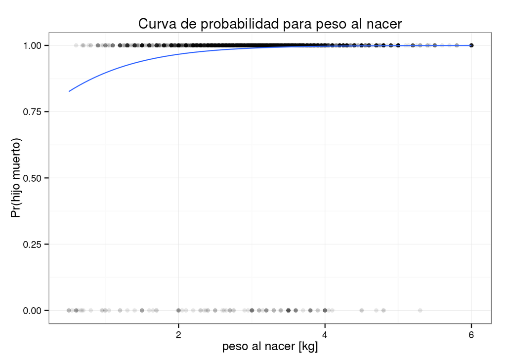

```r
ggplot(data = datos_orig) +
  aes(x = peso_al_nacer_kg, y = hijo_vivo_muerto) +
  geom_point(alpha = 0.1) +
  stat_smooth(method = 'glm', family = 'binomial', se = FALSE) +
  theme_bw() +
  labs(title = 'Curva de probabilidad para peso al nacer',
       x = 'peso al nacer [kg]',
       y = 'Pr(hijo muerto)')
```

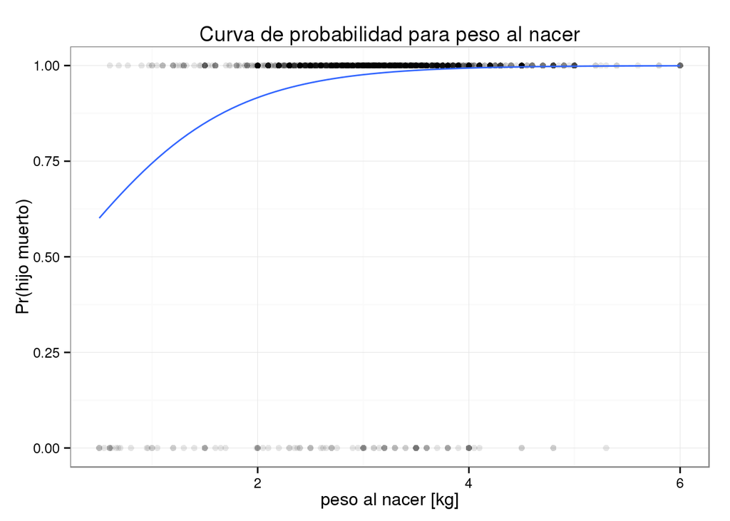

```r
ggplot(data = datos_orig[edad_muerte_meses <= 12 | edad_hijo_anios <= 1]) +
  aes(x = peso_al_nacer_kg, y = hijo_vivo_muerto) +
  geom_point(alpha = 0.1) +
  stat_smooth(method = 'glm', family = 'binomial', se = FALSE) +
  theme_bw() +
  labs(title = 'Curva de probabilidad para peso al nacer',
       x = 'peso al nacer [kg]',
       y = 'Pr(hijo muerto)')
```

- Hijo número: a partir del 4 hijo, es más probale perder un hijo

```r
# hijo_nro: posición del hijo dentro de la familia
datos_1m[edad_muerte_meses <= 12,
         table(hijo_nro, useNA = 'ifany')]
```

```
## hijo_nro
##   1   2   3   4   5   6   7
## 311 235 126  37  15   1   1
```

```r
datos_1m[edad_muerte_meses <= 12,
         table(hijo_nro, useNA = 'ifany') / .N]
```

```
## hijo_nro
##          1          2          3          4          5          6
## 0.42837466 0.32369146 0.17355372 0.05096419 0.02066116 0.00137741
##          7
## 0.00137741
```

```r
datos_0m[edad_hijo_anios <= 1,
         table(hijo_nro, useNA = 'ifany')]
```

```
## hijo_nro
##    1    2    3
## 5029  131    1
```

```r
datos_0m[edad_hijo_anios <= 1,
         table(hijo_nro, useNA = 'ifany') / .N]
```

```
## hijo_nro
##            1            2            3
## 0.9744235613 0.0253826778 0.0001937609
```

```r
datos_1m[edad_muerte_meses <= 12, sixnum(nro_hijos)]
```

```
##      Min       Q1     Mean   Median       Q3      Max
## 1.000000 2.000000 2.483471 2.000000 3.000000 7.000000
```

```r
datos_0m[edad_hijo_anios <= 1, sixnum(nro_hijos)]
```

```
##      Min       Q1     Mean   Median       Q3      Max
## 1.000000 1.000000 1.841891 2.000000 2.000000 7.000000
```

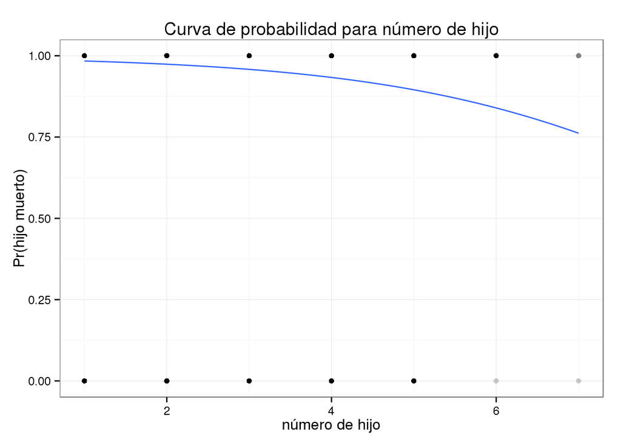

```r
ggplot(data = datos_orig) +
  aes(x = hijo_nro, y = hijo_vivo_muerto) +
  geom_point(alpha = 0.2) +
  stat_smooth(method = 'glm', family = 'binomial', se = FALSE) +
  theme_bw() +
  labs(title = 'Curva de probabilidad para número de hijo',
       x = 'número de hijo',
       y = 'Pr(hijo muerto)')
```

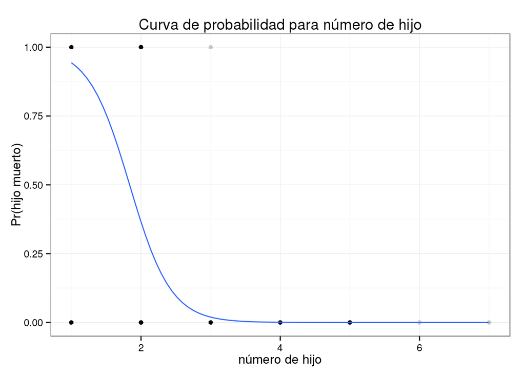

```r
ggplot(data = datos_orig[edad_muerte_meses <= 12 | edad_hijo_anios <= 1]) +
  aes(x = hijo_nro, y = hijo_vivo_muerto) +
  geom_point(alpha = 0.2) +
  stat_smooth(method = 'glm', family = 'binomial', se = FALSE) +
  theme_bw() +
  labs(title = 'Curva de probabilidad para número de hijo',
       x = 'número de hijo',
       y = 'Pr(hijo muerto)')
```